# Session 2: Data — Scraping, Google Trends & Nighttime Lights

GDP Growth Nowcasting Workshop — IDB Washington DC

Diego A. Guerrero

# Learning Objectives

- Retrieve data from **public APIs**
- Download website data.
- Download and process **Google Trends** search data
- Understand and download **NASA Nighttime Lights** satellite imagery
- Apply economic data preprocessing: **deflation**, **seasonal adjustment**, **growth rates**

# Scraping Economic Data

## Accessing Data on the Web

### Application Programming Interfaces (APIs)

- **Definition:** Structured gateways to query databases and retrieve data automatically.
- **Examples:**
  - [FRED API](https://fred.stlouisfed.org/docs/api/fred/) — US macro data
  - [World Bank Data API](https://datahelpdesk.worldbank.org/knowledgebase/topics/125589)
  - [IMF API](https://datahelp.imf.org/)

A key is typically required. Always read the documentation.

### FRED API

The `fredapi` library provides a Python interface to the Federal Reserve Economic Data:

```python
import pandas as pd
from fredapi import Fred

fred = Fred(api_key='YOUR_API_KEY_HERE')
sp500 = fred.get_series('SP500')
sp500 = pd.DataFrame(sp500, columns=["SP500"])
sp500.tail(5)
```

Install with: `conda install fredapi -y`

### Multiple Queries via Loop

```python
import requests
import pandas as pd

series   = ["SP500", "DJIA", "NASDAQCOM"]
api_key  = "YOUR_API_KEY_HERE"

df = pd.DataFrame()
for serie in series:
    url = (f"https://api.stlouisfed.org/fred/series/observations"
           f"?series_id={serie}&api_key={api_key}&file_type=json")
    resp = requests.get(url).json()
    dfi  = pd.DataFrame(resp["observations"])[["value", "date"]]
    dfi.set_index("date", inplace=True)
    dfi.index = pd.to_datetime(dfi.index)
    dfi.rename(columns={"value": f"fred_{serie}"}, inplace=True)
    dfi[f"fred_{serie}"] = pd.to_numeric(dfi[f"fred_{serie}"], errors="coerce")
    df = df.join(dfi, how="outer") if not df.empty else dfi
```

### Direct Web Requests

When no API is available, files can be retrieved via HTTP:

**Simple (pandas)**

```python
import pandas as pd

url = "https://example.com/data.csv"
df = pd.read_csv(url)
```

**With requests**

```python
import requests, pandas as pd
from io import StringIO

url = "https://example.com/data.csv"
response = requests.get(url)
if response.status_code == 200:
    df = pd.read_csv(StringIO(response.text))
```

### Advanced Requests and Headers

Most websites block automated requests. We add browser-style headers:

```python
import requests

hdr = {
    'User-Agent': (
        'Mozilla/5.0 (Windows NT 10.0; Win64; x64) '
        'AppleWebKit/537.36 (KHTML, like Gecko) '
        'Chrome/58.0.3029.110 Safari/537'
    )
}

url = "https://stats.gov.bb"   # BSS Barbados
r = requests.get(url=url, verify=None, headers=hdr).content
```

`headers` — the website thinks the request comes from a browser `verify=None` — disables SSL certificate checking (use with care)

### Parsing HTML with Beautiful Soup

```python
# Display-only: this cell hits a live website, so it is not executed at render
# time. Run it in the notebook during the session.
from bs4 import BeautifulSoup
import requests

hdr = {"User-Agent": "Mozilla/5.0"}
url = "https://stats.gov.bb/subjects/economic-statistics/trade-statistics/"
r = requests.get(url=url, verify=None, headers=hdr).content
soup = BeautifulSoup(r, "html.parser")

# Find all downloadable file links (BSS posts xlsx tables)
links = [
    link.get("href") for link in soup("a")
]
print(links[:5])
```

# Google Trends

## Google Trends as an Economic Indicator

Tracks real-time public interest in search terms — useful proxy for:

- **Consumer demand**: searches for products, services, and retail brands
- **Labour market**: job-search activity
- **Tourism**: hotel and travel queries from potential visitors
- **Uncertainty**: searches for economic news terms

**Key property**: freely available, monthly, with near-zero publication lag.

### Relevant Literature

**Choi & Varian (2012)** *Predicting the Present with Google Trends*

Google Trends predicts current unemployment, auto sales, and tourist destination visits.

**Varian (2023)** *Nowcasting with Google Trends*

Best practice: include trends data alongside traditional indicators.

**Cebrian & Domenech (2024)** *Addressing Google Trends Inconsistencies*

Inconsistencies across queries require re-scaling.

### Barbados Google Trends Keywords

Examples used in the nowcasting dataset:

- `barbados flights` / `barbados hotels` / `cruise barbados`
- `barbados crop over` / `barbados carnival`
- `barbados real estate`
- `massy` / `pricesmart` / `restaurants` (searches from Barbados)
- `flights miami` / `flights london` (searches from Barbados)

Downloads are available at trends.google.com — export as CSV (monthly, country = Barbados).

### Processing Google Trends Files

```python
import glob, re, pandas as pd
import os

PATH_RAW = "../data"

csv_files = glob.glob(os.path.join(PATH_RAW, "*multi*.csv"))

df0 = pd.DataFrame()
for csv in csv_files:
    dfi = pd.read_csv(csv, skiprows=1)
    dfi.rename(columns={"Month": "date"}, inplace=True)
    dfi["date"] = pd.to_datetime(dfi["date"])
    dfi.columns = [re.sub(r"\W+", "_", c).lower().strip("_")
                   for c in dfi.columns]
    dfi.set_index("date", inplace=True)
    df0 = pd.concat([df0, dfi], axis=1)

df0.columns = ["gt_" + c for c in df0.columns]
df0.to_csv(f"{PATH_RAW}/gtrends.csv")
print("Last date:", df0.index.max())
```

### Google Trends Data: Example

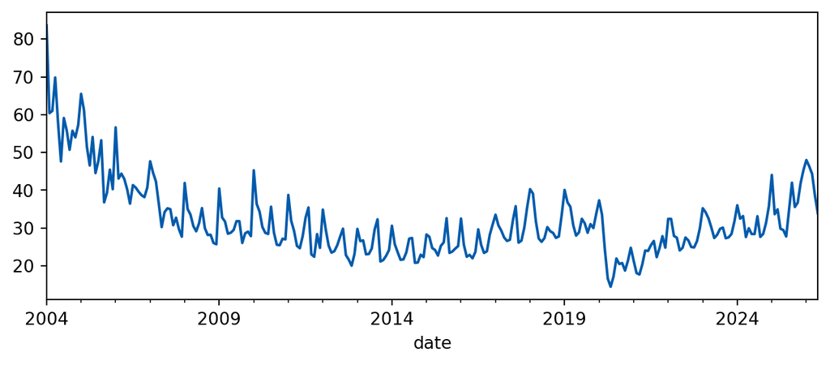

```python
import pandas as pd, numpy as np

PATH_RAW = "../data"
df = pd.read_csv(f"{PATH_RAW}/gtrends.csv",
                 parse_dates=True, index_col="date")

# Replace zeros with NaN (zero = no data, not zero activity)
df = df.replace(0, np.nan)

# Drop columns with >75% missing
df = df.dropna(axis=1, thresh=int(0.25 * len(df)))

# Create composite index (average across all terms)
df["gt_all_mean"] = df.mean(axis=1)

df["gt_all_mean"].plot(color="#005BAC", figsize=(8, 3))
```

# Satellite Nighttime Lights

## Why Nighttime Lights?

Satellite imagery of artificial light at night provides a proxy for:

- **Economic activity** — especially the informal sector
- **Electrification and infrastructure**
- **Urban growth**
- **Disruption** — storms, blackouts, plant shutdowns

Available at fine spatial (500 m) and **daily** resolution, with no publication lag — only a processing delay of a day or two.

## NTL in The Bahamas

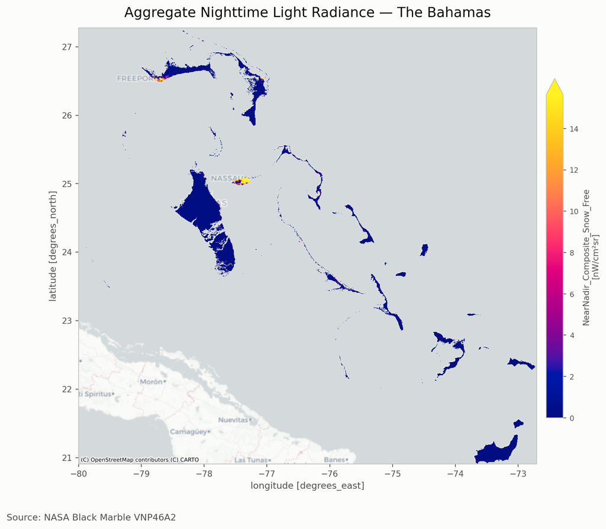

Almost all of the country’s light is Nassau and Freeport.

### NASA Black Marble VIIRS

- **Product**: VNP46A2 (daily) and VNP46A3 (monthly, cloud-free composite)
- **Variable**: radiance in nW/cm²/sr
- **Coverage**: global, 500 m pixels, from 2012
- **Access**: NASA Earthdata — a free account and a token
- **Python library**: `blackmarblepy` (run in the `geo` environment)

Note the start date: **2012**.

### Workflow Overview

1. **Register** at ladsweb.modaps.eosdis.nasa.gov and obtain a token
2. **Download the country boundary** (GADM)
3. **Download the tiles** covering the country
4. **Aggregate** pixel values over the area or the sites you care about
5. **Save** the resulting series

### Downloading the Monthly Composite

```python
from blackmarble import BlackMarble
import pandas as pd
import geopandas as gpd

shape = "https://geodata.ucdavis.edu/gadm/gadm4.1/shp/gadm41_BHS_shp.zip"
gdf = gpd.read_file(shape)

token = "YOUR_EARTHDATA_TOKEN_HERE"
bm = BlackMarble(token=token)

# VNP46A3 = the MONTHLY cloud-free composite
df_ntl = bm.raster(
    gdf,
    product_id="VNP46A3",
    date_range=pd.date_range("2012-01-01", "2026-01-01", freq="ME"),
)

# Aggregate: sum all pixels over The Bahamas
dfx = (
    df_ntl["NearNadir_Composite_Snow_Free"]
    .sum(dim=["x", "y"])
    .rename("NearNadir_Composite_Snow_Free")
    .to_dataframe()
)
dfx.index.name = "date"
dfx.to_csv("../data/blk_ntl.csv")
```

`freq="ME"` is month-end. (`"M"` means the same thing but is deprecated in pandas 2.x and will stop working.)

### The Monthly Series

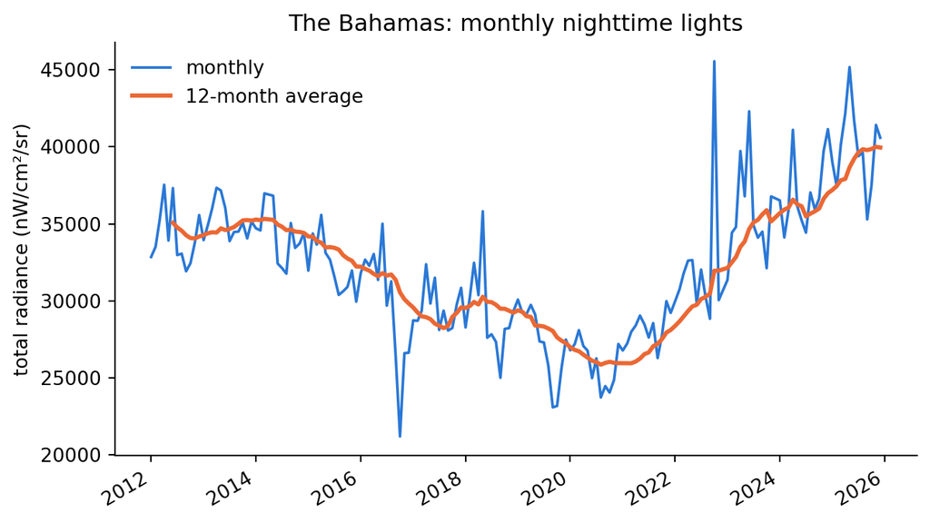

```python
import pandas as pd

df = pd.read_csv("../data/blk_ntl.csv", parse_dates=["date"])
s = df.set_index("date")["NearNadir_Composite_Snow_Free"].dropna()

# The last month is an incomplete composite - drop it
s = s.loc[:"2025-12-01"]

ax = s.plot(color="#2a78d6", linewidth=1.4, figsize=(7.5, 4.4))
s.rolling(12, min_periods=6).mean().plot(
    ax=ax, color="#eb6834", linewidth=2.2)
ax.set_title("The Bahamas: monthly nighttime lights")
ax.set_ylabel("total radiance (nW/cm²/sr)")
ax.set_xlabel("")
ax.legend(["monthly", "12-month average"], frameon=False)
ax.spines[["top", "right"]].set_visible(False)
```

## Two questions, two functions

| Question | Function | Input |
| --- | --- | --- |
| How lit is this **area**? | `processHD5_shape` | a boundary polygon |
| How lit is this **site**? | `processHD5` | a list of latitude/longitude points |

Both live in `ntl_helpers.py`. The site version is fed by each country’s `raw/Coordinates.xlsx`.

A satellite pixel is about 464 m across, so sites closer together than that share a pixel and are grouped into one cluster rather than treated as separate series.

# Oil, Gas and Nighttime Lights

## Why energy infrastructure is a good test

- Flares and industrial plant are **bright, continuous and spatially fixed**
- Start-ups and shutdowns have **known dates**, so the satellite record can be checked against something we already know
- For Guyana and Trinidad & Tobago, the energy sector **is** the macroeconomic story

Nighttime lights are usually sold as a proxy for GDP. Here we can do something stricter: test whether the lights move when we *know* the economy moved.

## Guyana: offshore production

[figure not shown]

Before 2019, the ocean reads the same as empty water.

## Guyana: onshore

[figure not shown]

## Trinidad & Tobago

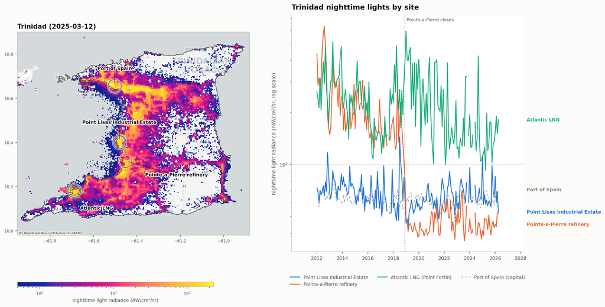

Pointe-à-Pierre refinery closed in November 2018, and lights fall by about three quarters and stay down. Point Lisas (petrochemical estate) still operating, and its lights are flat throughout, tracking Port of Spain.

### Reading the charts

- **Light is not output.** An offshore flare measures flaring, not production. Guyana’s flaring fell under regulatory pressure so brightness declines even if output grows.
- **What lights are good at**: detecting *new capacity* and *shutdowns* — discrete, dateable events.
- **What they are poor at**: estimating the *level* of production once a facility is running steadily.
- **Monitoring trends over time**: useful for direction and turning points at a site — is this place busier than a year ago? — provided you compare it against a benchmark rather than reading the level on its own.

# Natural Disasters

## Why disasters are the clearest case

A hurricane removes electricity from a known place on a known night. That makes it the cleanest available test of whether the satellite is measuring anything real.

Two cautions before reading these charts:

- **Storms are clouds.** Cloud blocks the sensor, so some of the drop on the night itself is obstruction rather than darkness. The maps below use dates a few days either side of landfall for this reason.
- **The recovery matters more than the drop.** A one-night dip is weather. Weeks below the pre-storm mean is damage.

## Jamaica — Hurricane Melissa, October 2025

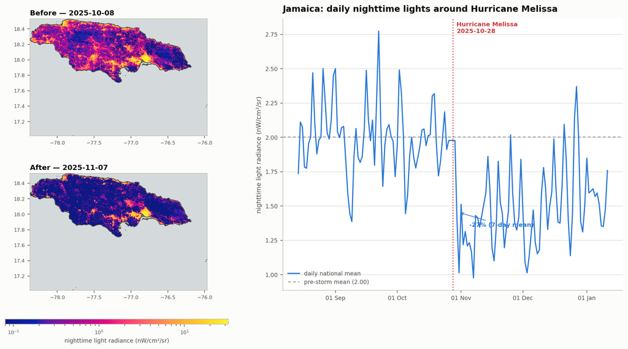

National lights fall **27%** over the week after landfall, and are still below the pre-storm average two months later.

## The Bahamas — Hurricane Dorian, September 2019

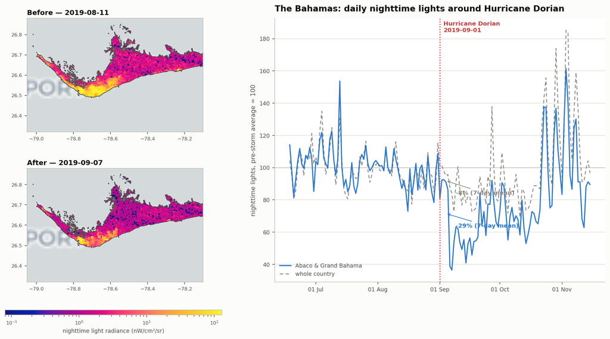

Abaco and Grand Bahama fall **29%**; the country as a whole only **8%**. The same storm looks minor or severe depending on the level you measure it at. Maps show Grand Bahama, where Freeport is the brightest thing in the country.

## Barbados — Hurricane Beryl, July 2024

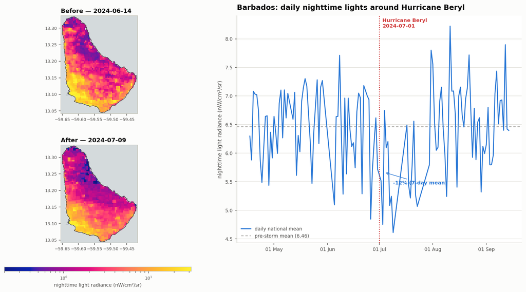

A **12%** fall over the following week — Beryl passed to the south, so Barbados caught the edge rather than the eye.

## Belize — Hurricane Lisa, November 2022

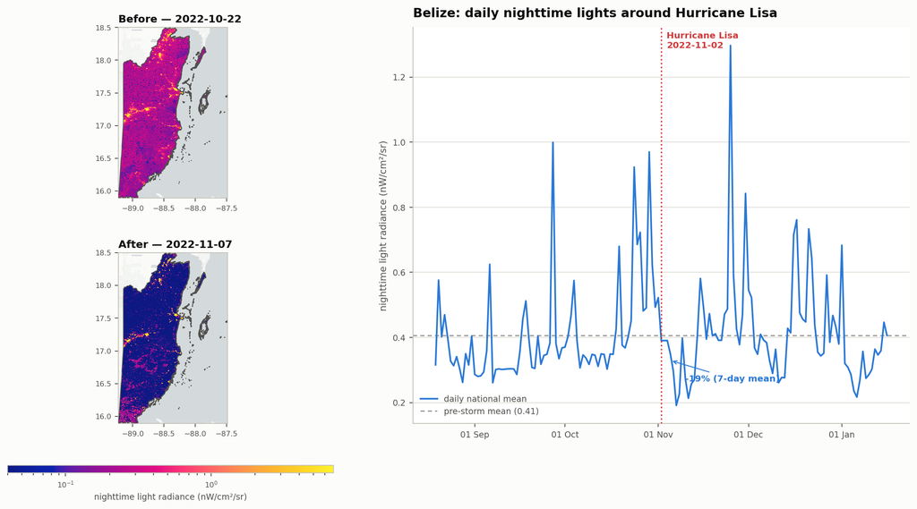

A **19%** fall. Lisa made landfall at Belize City, and the maps show how much of the country’s light comes from that one corridor.

# Economic Data Preprocessing

## Three Standard Transformations

| Step | Purpose | Method |
| --- | --- | --- |
| **Deflation** | Remove price-level changes | Divide by CPI, multiply by base-year CPI |
| **Seasonal Adjustment** | Remove calendar seasonality | `seasonal_decompose` trend component |
| **Growth rates** | Achieve stationarity | Quarter-over-quarter `pct_change()` |